# Instalación de R y Rstudio

Pepi Amodeo

Agosto 2022

[Inicio](https://pepiamodeo.github.io/cursotallerIADO/)

Instituto Argentino de Oceanografía (CONICET UNS) Bahía Blanca, Argentina

# Objetivos

- Instalar `R`
- Instalar `Rstudio`
- Conocer material web vinculado con el desarrollo `R`, como software libre

# R, Rstudio y el software libre

`R` es un software libre y de código abierto disponible bajo una Licencia Pública General [GNU](https://en.wikipedia.org/wiki/GNU_General_Public_License).

*Software libre* no es lo mismo que *software gratis*.

`R` puede ser instalado y utilizado de manera gratuita. Las licencias libres permiten a los/as usuarios/as usar, copiar, estudiar y modificar el software de cualquier manera. De este modo, el software crece y mejora gracias al aporte y las ideas de una comunidad. Esto se gestiona en la forma de librerías que pueden ir instalándose como extensiones del software base, las cuales se publican y acceden a través de la red de archivos del proyecto de `R` llamado `CRAN` (The Comprehensive `R` Archive Network). Además, cualquier usuario puede desarrollar una librería o paquete y publicarlo sencillamente a través de un repositorio personal como [Git-hub](https://github.com/).

`RStudio` es un entorno de desarrollo integrado para el lenguaje de programación `R` (y otros) disponible también bajo una Licencia Pública General (AGPL v3), accesible en ediciones tanto gratuitas como pagas. Provee al usuario de una interfaz organizada y con herramientas que facilitan y extienden las posibilidades de trabajo con `R`.

# Paso a paso

Las siguientes demostraciones están hechas enfocadas en usuarios/as de Windows 10. Para otros sistemas operativos, seguir las indicaciones en los sitios de los desarrolladores.

## ¿Cómo instalar `R`? Descargar por primera vez.

https://www.r-project.org/

En la página web del proyecto de `R` *The R Project for Statistical Computing* (link al margen derecho) se puede acceder a los links de descarga y mucha información relacionada con el proyecto.

1- Getting Started: clickear en “download R”

2- Seleccionar el mirror de Argentina Universidad Nacional de La Plata

3- “download R for Windows” (a menos que tengas otro sistema operativo)

4- “install R for the first time”

5- El link superior descargará la última versión (“Download R…”)

[figure not shown]

Una vez descargado, ejecutar el instalador y seguir los pasos (ante la duda recomiendo ejecutarlo con permisos de administrador si es posible: botón derecho/“Run as administrator”). En cada paso se pueden dejar las opciones que aparecen por defecto y seguir adelante (sugerencia que solo hago porque confío en el proyecto). `R` se instala en el directorio indicado durante el proceso de instalación (comunmente en `.../Archivos de Programa/R` y las liberías o paquetes en `.../Documentos/R/win-library`.

## ¿Cómo instalar Rstudio?

https://rstudio.com/

Una vez instalado `R`, podemos proceder a instalar la interfaz `Rstudio`. En e link del margen derecho, accedemos a su web. En la sección de descargas seleccionar el software `Rstudio Desktop`. Una vez descargado seguir las indicaciones (misma sugerencia que antes).

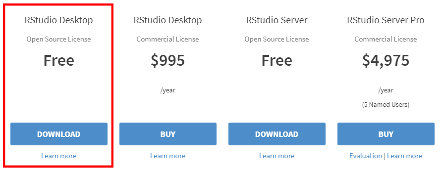

## ¿Cómo correrlo?

[figure not shown]

De ahora en más, solo vamos a ejecutar el software `Rstudio`, por lo tanto sólo nos va a importar tener un acceso directo a `Rstudio` a mano.

## Información sobre `R`

Dado que es un software en permanente desarrollo por una comunidad creciente, existen muchas fuentes de donde obtener información para saber cómo usarlo o cómo resolver dudas específicas. Recordá que la búsqueda activa de ayuda y la consulta perminanete a estas fuentes son parte de las reglas básicas de un/a usuario/a de `R`, y por supuesto la colaboración con otros/as.

- [Rhelp](https://www.r-project.org/help.html) La ayuda de `R` es el primer lugar.
- [stack overflow](https://stackoverflow.com/)
- [Rpubs](https://rpubs.com/)
- [muuuuuuuchos libros](https://www.r-project.org/doc/bib/R-books.html)
- [Cookbook R](http://www.cookbook-r.com/)
- R Graph Gallery

# Concluyendo

[figure not shown]

Ahora ya está `R` instalado y lo utilizaremos a través de la interfaz de `Rstudio`. Bienvenido/a a la fascinante (y ondulante) senda del software libre para la exploración y el análisis de datos. Ahora a andar… sos *libre*.

[Volver al índice](https://pepiamodeo.github.io/cursotallerIADO/)